# Predict annual surface DOC

Fit a BRT model to predict DOC from environmental data and apply it to new data.

Author

Thelma Panaïotis

## Set-up and load data

```r
source("utils.R")
load("data/02.ann_surf.Rdata")
output_filename <- "data/03.doc_surf_ann_pred.Rdata"

df_fit <- df_ann_surf_fit
df_pred <- df_ann_surf_pred
```

## Data preparation

### Variable roles

```r
# Response variable
resp_var <- c("log_doc_surf", "doc_surf") # keep both untransformed and transformed predictor
# Explanatory variables
exp_vars <- df_fit %>% select(temperature_surf:par) %>% colnames()
# Metadata
meta_vars <- c("lon", "lat", "season")
```

## Data exploration

### Distribution of response variable

We want the response variable to be ~normally distributed. Let’s plot the distribution of log_doc_surf.

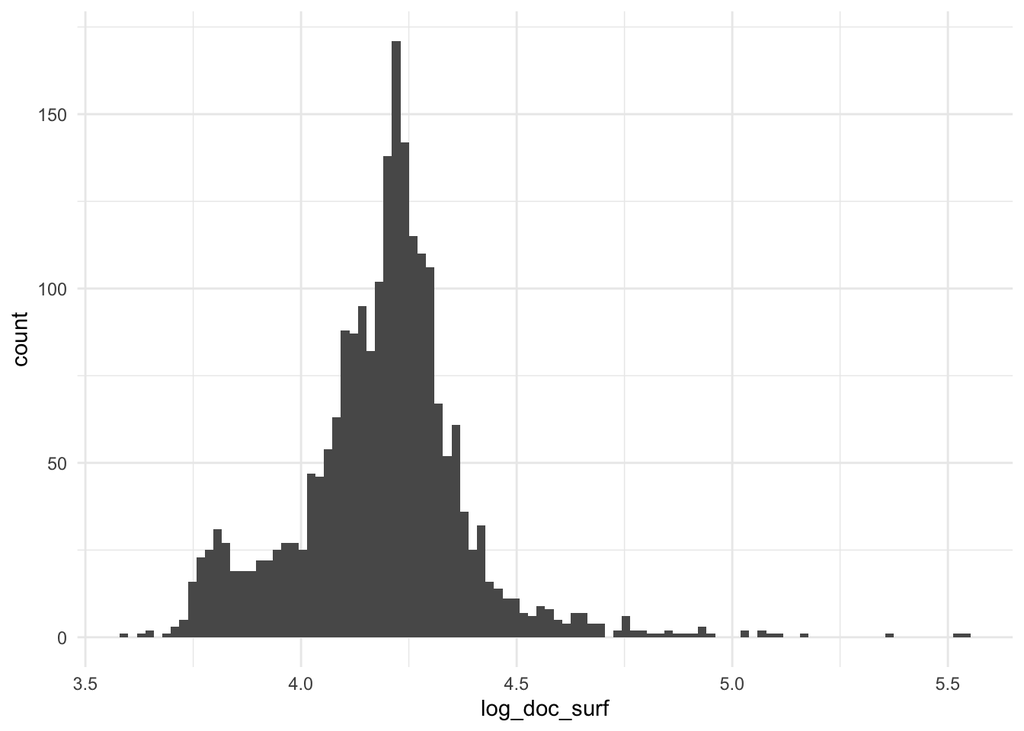

```r
ggplot(df_fit) + geom_histogram(aes(x = log_doc_surf), bins = 100)
```

Not too bad! Let’s proceed.

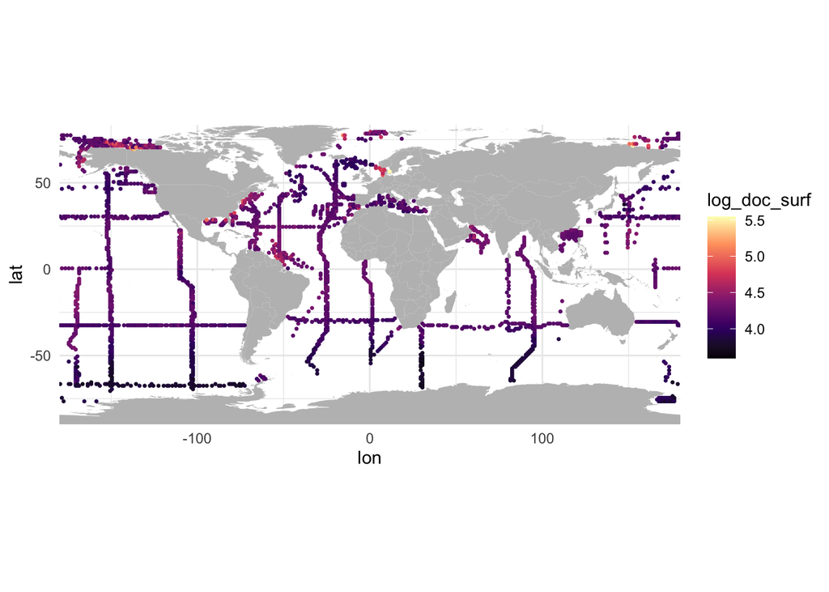

```r
ggplot(df_fit) +
  geom_polygon(data = world, aes(x = lon, y = lat, group = group), fill = "grey") +
  geom_point(aes(x = lon, y = lat, colour = log_doc_surf), size = 0.5) +
  ggplot2::scale_colour_viridis_c(option = "A") +
  coord_quickmap(expand = 0)
```

### Explanatory variables

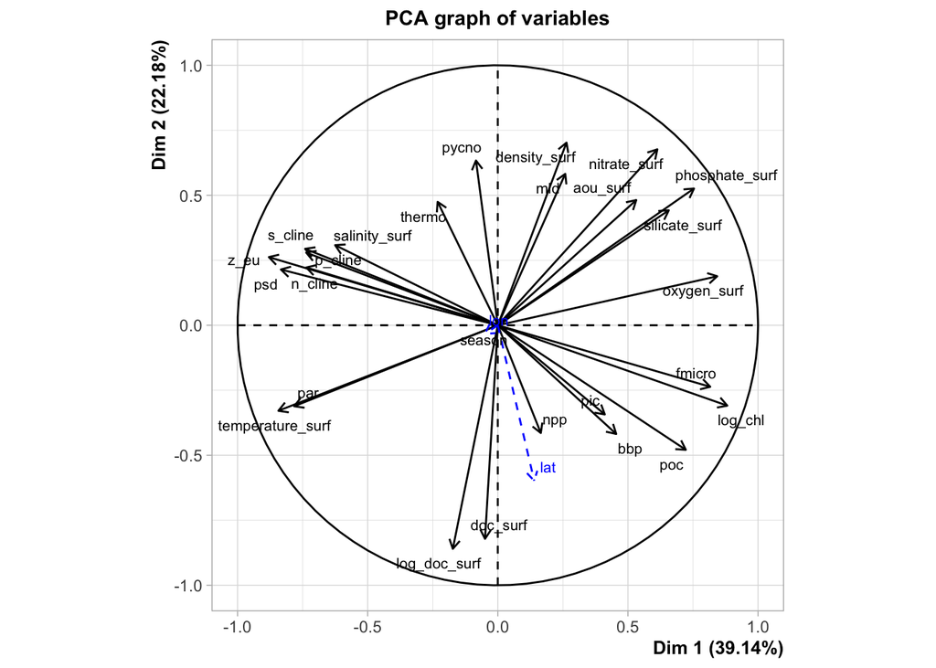

```r
# Need to remove lon and lat and to scale because units differ between variables
df_pca <- df_fit %>% select(c(lon, lat, doc_surf, log_doc_surf, everything()))
pca_all <- FactoMineR::PCA(df_pca, quanti.sup = 1:2, scale.unit = TRUE, graph = FALSE)

# Plot eigenvalues
#plot_eig(pca_all)

# Plot variables
plot(pca_all, choix = "var", axes = c(1, 2), cex = 0.7)
```

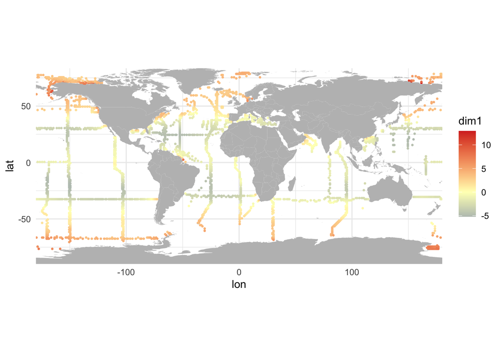

```r
## Get coordinates of individuals
inds <- pca_all$ind$coord %>% as_tibble()
# Set nice names for columns
colnames(inds) <- str_c("dim", paste(c(1:ncol(inds))))
# And join with initial dataframe of objects
inds <- df_fit %>% bind_cols(inds)

# Plot maps of PCA projections
ggmap(inds, "dim1", type = "point", palette = div_pal)
```

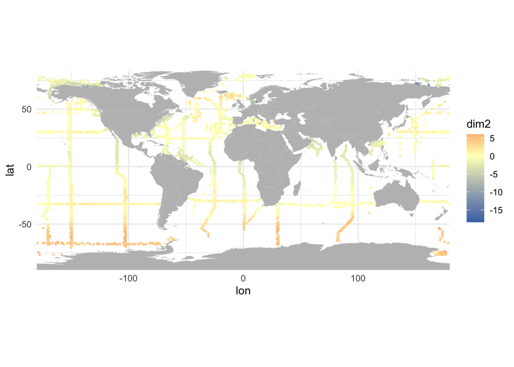

```r
ggmap(inds, "dim2", type = "point", palette = div_pal)
```

## Data split

To better assess the performance of our model and get a distribution of R² instead of a single value, we will use nested cross-validation.

Instead of splitting the data into train and test sets and get a single estimate of R² on the test set, we will use nested cross-validation so that we have several repeats of train/test splits and thus a distribution of R² values. For each fold, a second cross-validation is performed within the training set in order to tune the hyperparameters.

We use 10-fold cross-validation:

- 10% of data for testing
- 90% of data for training. This subset is used for nested cross-validation with:
  - 10% of data for validation
  - 90% of data for learning

Two different methods for data splitting are used:

- stratified on deciles of the response variable (`doc_log`)
- spatial cross-validation using blocks

```r
# Transform dataframe to sf object for spatial CV.
df_sf <- st_as_sf(df_fit, coords = c("lon", "lat"), crs = 4326)

set.seed(seed)
# Bind together folds of both nested_cv
folds <- bind_rows(
  # Stratified CV on deciles of response variable
  nested_cv(
    df_fit,
    outside = vfold_cv(v = 10, strata = log_doc_surf, breaks = 9),
    inside = vfold_cv(v = 10, strata = log_doc_surf, breaks = 9)) %>%
    mutate(cv_type = "stratified"),
  # Spatial CV
  nested_cv(
    df_sf,
    outside = spatial_block_cv(v = 10),
    inside = spatial_block_cv(v = 10)) %>%
    mutate(cv_type = "spatial")
)
```

## Model definition

Let’s define a boosted regression trees model, with tunable hyperparameters:

- `trees`: number of trees
- `tree_depth`: maximum depth (i.e. number of splits) in a tree
- `min_n`: minimum number of objects in a node to split further
- `learn_rate`

```r
# Define a lightgbm model with hyperparameters to tune
xgb_spec <- boost_tree(
  trees = tune(),
  tree_depth = tune(),
  min_n = tune(),
  learn_rate = tune()
) %>%
  set_mode("regression") %>%
  set_engine("lightgbm")
```

We also generate the formula from the explanatory variables. We also keep doc for now, but it will be removed from predictors when generating the recipe within the gridsearch.

```r
# Generate formula from list of explanatory variables
xgb_form <- as.formula(paste("log_doc_surf ~ ", paste(c("doc_surf", exp_vars), collapse = " + "), sep = ""))
```

Finally, let’s define the grid for the gridsearch (only one grid is used for all folds).

```r
# Define one grid for all folds
set.seed(seed)
xgb_grid <- grid_latin_hypercube(
  trees(),
  learn_rate(),
  tree_depth(),
  min_n(),
  size = 30
)
```

## Models fitting

Let’s loop on cv folds. For each fold, a gridsearch is performed using nested CV on training data, and performance are assessed on the test data. This is run in parallel on 10 cores.

```r
res <- lapply(1:nrow(folds), function(i){

  message(paste0("Processing fold ", i, " out of ", nrow(folds)))

  ## Get fold
  x <- folds[i,]

  ## Train and test sets
  df_train <- analysis(x$splits[[1]]) %>% as_tibble()
  df_test <- assessment(x$splits[[1]]) %>% as_tibble()

  ## Recipe
  xgb_rec <- recipe(xgb_form, data = df_train) %>%
    update_role(doc_surf, new_role = "untransformed outcome")

  ## Workflow
  xgb_wflow <- workflow() %>%
    add_recipe(xgb_rec) %>%
    add_model(xgb_spec)

  ## Gridsearch
  set.seed(seed)
  doParallel::registerDoParallel(n_cores)
  xgb_res <- tune_grid(
    xgb_wflow,
    resamples = x$inner_resamples[[1]],
    grid = xgb_grid,
    metrics = metric_set(rmse),
    control = control_grid(save_pred = TRUE)
  )
  best_params <- select_best(xgb_res)

  ## Final fit
  final_xgb <- finalize_workflow(
    xgb_wflow,
    best_params
  )
  final_res <- fit(final_xgb, df_train)

  ## Prediction on outer folds
  preds <- predict(final_res, new_data = df_test) %>%
    bind_cols(df_test %>% select(log_doc_surf))

  ## Model explainer
  # Select only predictors
  vip_train <- xgb_rec %>% prep() %>% bake(new_data = NULL, all_predictors())

  # Explainer
  xgb_explain <- explain_tidymodels(
      model = extract_fit_parsnip(final_res),
      data = vip_train,
      y = df_train %>%  pull(log_doc_surf),
      verbose = FALSE
    )

  # Variable importance
  full_vip <- model_parts(xgb_explain) %>%
    bind_rows() %>%
    filter(variable != "_baseline_")

  # CP profiles for all variables
  cp_profiles <- lapply(exp_vars, function(my_var){
    model_profile(explainer = xgb_explain, variables = my_var)$cp_profiles %>% as_tibble()
  }) %>%
    bind_rows()

  ## Predict new data
  new_preds <- augment(final_res, new_data = df_pred %>% mutate(doc_surf = NA)) %>%
    select(-doc_surf) %>%
    rename(pred_doc_log = .pred) %>%
    relocate(pred_doc_log, .after = lat)

  doParallel::stopImplicitCluster()

  ## Return results
  return(tibble(
      resp = resp_var[2],
      season = "0",
      cv_type = x$cv_type,
      fold = x$id,
      preds = list(preds),
      importance = list(full_vip),
      cp_profiles = list(cp_profiles),
      new_preds = list(new_preds)
    ))
}) %>%
  bind_rows()
```

## Save results

```r
save(res, file = output_filename)
```